# Exploratory analysis of Welsh Health Survey

fatemeh.torabi@ice.cam.ac.uk

2025-04-11

# Abstract

**Background:** Wellbeing is a key indicator of population health, influenced by a range of social, physical, and demographic factors. Understanding how Body Mass Index (BMI), employment status and general health status relate to wellbeing can inform public health strategies.

**Objective:** This study investigates whether overall wellbeing in the adult population varies by BMI, employment status and general health status.

# Welsh Health Survey

Overview of the dataset

|  | wbSatis | wbWorth | wbHappy | wbAnx | ...5 | wt_adult | Wellscore | Sex | Age5yrm | health | Work | qualhi | wbsatis1 | wbsatis2 | wbsatis3 | wbsatis4 | wbworth1 | wbworth2 | wbworth3 | wbworth4 | wbhappy1 | wbhappy2 | wbhappy3 | wbhappy4 | wbanx1 | wbanx2 | wbanx3 | wbanx4 | htcm | … |
| --- | --- | --- | --- | --- | --- | --- | --- | --- | --- | --- | --- | --- | --- | --- | --- | --- | --- | --- | --- | --- | --- | --- | --- | --- | --- | --- | --- | --- | --- | --- |
| 1 | 9 | 8 | 8 | 0 |  | 0.7907761 | 20 | 1 | 12 | 3 | 9 | -9 | 4 | 3 | 2 | 2 | 3 | 2 | 2 | 2 | 3 | 2 | 2 | 2 | 1 | 1 | 1 | 1 | 177.8 | … |
| 2 | 8 | 8 | 9 | 1 |  | 1.3394688 | 17 | 2 | 4 | 3 | 2 | 1 | 3 | 2 | 2 | 2 | 3 | 2 | 2 | 2 | 4 | 3 | 2 | 2 | 1 | 1 | 1 | 1 | 165.1 | … |
| 3 | 0 | 0 | 0 | 10 |  | 0.8908539 | 29 | 2 | 6 | 1 | 1 | 1 | 1 | 1 | 1 | 1 | 1 | 1 | 1 | 1 | 1 | 1 | 1 | 1 | 4 | 3 | 2 | 2 | 149.86 | … |
| 4 | 5 | 5 | 5 | 5 |  | 0.8885045 | 23 | 1 | 7 | 2 | 2 | 1 | 2 | 1 | 2 | 1 | 2 | 1 | 2 | 1 | 2 | 1 | 2 | 1 | 3 | 3 | 1 | 2 | 170.18 | … |
| 5 | 5 | 5 | 5 | 8 |  | 0.8840006 | 28 | 2 | 13 | 2 | 9 | 1 | 2 | 1 | 2 | 1 | 2 | 1 | 2 | 1 | 2 | 1 | 2 | 1 | 4 | 3 | 2 | 2 | 152.4 | … |
| 6 | 6 | 6 | 7 | 0 |  | 0.9817888 | 35 | 1 | 7 | 1 | 2 | 1 | 2 | 1 | 2 | 1 | 2 | 1 | 2 | 1 | 3 | 2 | 2 | 2 | 1 | 1 | 1 | 1 | 152.4 | … |
| 7 | 7 | 6 | 7 | 7 |  | 0.9422476 | 33 | 2 | 6 | 1 | 11 | 1 | 3 | 2 | 2 | 2 | 2 | 1 | 2 | 1 | 3 | 2 | 2 | 2 | 4 | 3 | 2 | 2 | 157.48 | … |
| 8 | 5 | 6 | 7 | 0 |  | 0.7018079 | 36 | 1 | 13 | 1 | 9 | -9 | 2 | 1 | 2 | 1 | 2 | 1 | 2 | 1 | 3 | 2 | 2 | 2 | 1 | 1 | 1 | 1 | 165.1 | … |
| 9 | 8 | 9 | 9 | 1 |  | 0.6629643 | 40 | 2 | 12 | 1 | 10 | 0 | 3 | 2 | 2 | 2 | 4 | 3 | 2 | 2 | 4 | 3 | 2 | 2 | 1 | 1 | 1 | 1 | 165.1 | … |
| 10 | 8 | 8 | 7 | 0 |  | 0.9168236 | 24 | 2 | 13 | 2 | 9 | -9 | 3 | 2 | 2 | 2 | 3 | 2 | 2 | 2 | 3 | 2 | 2 | 2 | 1 | 1 | 1 | 1 | 160.02 | … |

[output cut: 10 more lines]

Derive variables

The data preparation stage included defining variable levels and ensuring consistency across existing variables, these then been reduced to an analysis ready dataset which is demonstrated below

|  | wellb_score | BMI_cat | Work | genhlth | age_group | Sex |
| --- | --- | --- | --- | --- | --- | --- |
| 1 | 25 | Overweight | Unknown | Not good | 70-74 | Male |
| 2 | 26 | Healthy | Unemployed | (Don’t know) | 30-34 | Female |
| 3 | 10 | Obese | Employed | (Refusal) | 40-44 | Female |
| 4 | 20 | Healthy | Unemployed | (Refusal) | 45-49 | Male |
| 5 | 23 | Obese | Unknown | (Don’t know) | 75+ | Female |
| 6 | 19 | Obese | Unemployed | Not good | 45-49 | Male |
| 7 | 27 | Overweight | Unknown | Not good | 40-44 | Female |
| 8 | 18 | Healthy | Unknown | Not good | 75+ | Male |
| 9 | 27 | Overweight | Unknown | Good | 70-74 | Female |
| 10 | 23 | Obese | Unknown | Good | 75+ | Female |

[output cut: 10 more lines]

Cleaning data

# Descriptive statistics

To summarize data using the tableone package in R, you can create descriptive statistics tables for both continuous and categorical variables in one go. This approach is particularly useful for summarizing key characteristics of your variables before conducting formal statistical tests.

| **Characteristic** | **Female**, N = 3,351<sup>1</sup> | **Male**, N = 3,323<sup>1</sup> |
| --- | --- | --- |
| wellb_score | 24.42 (5.97) | 24.45 (5.86) |
| BMI_cat |  |  |
| Healthy | 1,116 (33%) | 1,117 (34%) |
| Obese | 761 (23%) | 765 (23%) |
| Overweight | 1,178 (35%) | 1,147 (35%) |
| Underweight | 273 (8.1%) | 265 (8.0%) |
| Unknown | 23 (0.7%) | 29 (0.9%) |
| Work |  |  |
| Employed | 348 (10%) | 279 (8.4%) |
| Unemployed | 3,003 (90%) | 3,044 (92%) |
| genhlth |  |  |
| (Don’t know) | 489 (15%) | 482 (15%) |
| (Refusal) | 171 (5.1%) | 170 (5.1%) |
| Fairly good | 1,156 (34%) | 1,214 (37%) |
| Good | 467 (14%) | 435 (13%) |
| Not good | 1,068 (32%) | 1,022 (31%) |
| age_group |  |  |
| 16-19 | 275 (8.2%) | 245 (7.4%) |
| 20-24 | 258 (7.7%) | 228 (6.9%) |
| 25-29 | 252 (7.5%) | 272 (8.2%) |
| 30-34 | 328 (9.8%) | 269 (8.1%) |
| 35-39 | 287 (8.6%) | 327 (9.8%) |
| 40-44 | 400 (12%) | 389 (12%) |
| 45-49 | 413 (12%) | 410 (12%) |
| 50-54 | 454 (14%) | 389 (12%) |
| 55-59 | 374 (11%) | 359 (11%) |
| 60-64 | 201 (6.0%) | 274 (8.2%) |
| 65-69 | 70 (2.1%) | 101 (3.0%) |
| 70-74 | 34 (1.0%) | 36 (1.1%) |
| 75+ | 5 (0.1%) | 24 (0.7%) |

<sup>1</sup> Mean (SD); n (%)

# Distribution of Wellbeing Score

First, we will explore the distribution of the wellbeing score to understand its shape and characteristics.

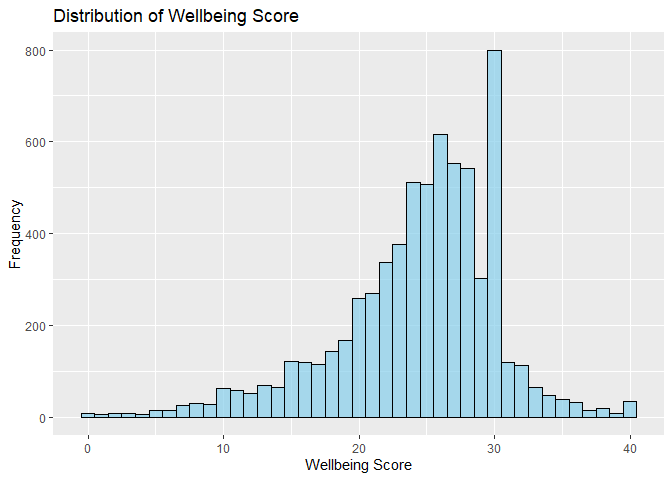

# Wellbeing Score by Age Group (Optional)

Exploring the relationship between wellbeing score and age group can provide additional insights.

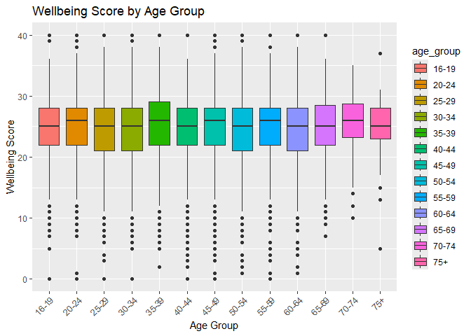

# Relationship Between Wellbeing Score and BMI Category

We will now explore how wellbeing score varies by BMI category. We can use a boxplot to compare the wellbeing scores across different BMI categories.

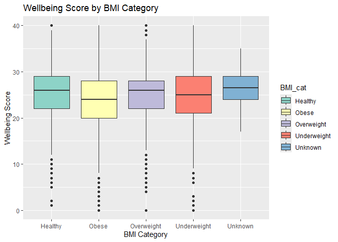